# Round numbers Pre-registered Study: 1300 Participants

This notebook is a supplementary material for the paper submission. All the ID codes shown in the notebook (e.g., worker ID, HIT ID, assignment ID) have been anonymized.

## Set constants and define functions

```r
library(DT)
library(tidyverse)
library(lubridate)
library(knitr)
library(scales)
library(broom)
library(effectsize)
library(tidyr)
library(comprehenr)
library(IRdisplay)
library(hrbrthemes)

options(repr.plot.width=8, repr.plot.height=6)
```

```
NOTE: Either Arial Narrow or Roboto Condensed fonts are required to use these themes.

      Please use hrbrthemes::import_roboto_condensed() to install Roboto Condensed and

      if Arial Narrow is not on your system, please see https://bit.ly/arialnarrow
```

```r
# set style
theme_set(theme_bw())

# study date
study_date <- "20210723"

# accept responses between (1 - margin) and (1 + margin) times exact answer as correct
margin <- 0.10

# set figure directory
figure_dir <- "figures"

exact_values <- tribble(
    ~question_type, ~question, ~question_pretty, ~actual_exact, ~actual_approx, ~google_instant_answer,
    "recall", "trap_1", "Trap: California population", 39613493, 39613493, 39466917,
    "recall", "enroll_1", "Enrollment: number of accepted transfer applicants", 28752, 30000, NA,
    "recall", "enroll_2", "Enrollment: number of transer applicants", 41282, 40000, NA,
    "recall", "hondura_1", "Immigrants: Hondurans in the U.S. 2000", 282852, 300000, NA,
    "recall", "hondura_2", "Immigrants: Hondurans in the U.S. now", 487745, 500000, NA,
    "recall", "frick_1", "Museum: Size of addition", 40108, 40000, NA,
    "recall", "frick_2", "Museum: Size of addition for art", 3792, 4000, NA,
    "calculate", "enroll", "Enrollment: percentage of accepted transfer applicaents", 28752/41282*100, 30000/40000*100, NA,
    "calculate", "hondura", "Immigrants: Increase in Hondurans in the U.S. since 2000", 487745 - 282852, 500000 - 300000, NA,
    "calculate", "frick", "Museum: Percentage of addition for art", 3792/40108*100, 4000/40000*100, NA
)

# correct reading comprehension options
correct_comprehension_options <- c(
    "This study is a psychology experiment and I'm not being paid based on the correctness of my answers",
    "I'm supposed to take my best guesses",
    "I'm not supposed to look up answers on the internet",
    "I'm supposed to work from information in my head and not record or write down any information I see"
)
incorrect_comprehension_option <- "I'm supposed to type random answers, not my best guesses"

# helper function to read qualtrics csv data
# note: must add option to remove linebreaks when downloading
# see here: https://stackoverflow.com/a/50314806
read_qualtrics <- function(filename) {
    headers <- read_csv(filename, col_names = FALSE, n_max = 1)
    qualtrics <- read_csv(filename, skip = 3, col_names = FALSE)
    colnames(qualtrics) <- headers
    qualtrics$filename <- filename
    qualtrics
}

# helper function to batch read mturk csv data
# forces survey codes to be numeric
read_mturk_with_numeric_surveycode <- function(filename) {
    mturk <- read.csv(filename) %>%
        mutate(Answer.surveycode = as.numeric(as.character(Answer.surveycode)))
}

# helper function to display table in html format
display_table <- function(table) {
    table %>% kable("html") %>% as.character() %>% display_html()
}
```

## Load and clean data

```r
# read in qualtrics responses for this experiment
# remove some empty fields
qualtrics <- read_qualtrics(sprintf('data/anon_qualtrics_responses_%s.csv', study_date)) %>%
    filter(Finished == TRUE) %>%
    select(-workerId, -hitId)
```

```r
# read in mturk info for this HIT
mturk <- read_mturk_with_numeric_surveycode(sprintf('data/anon_mturk_codes_%s.csv', study_date)) %>%
    rename(random_verification_code = Answer.surveycode)
```

```r
print(sprintf(
    "Mturk length: %d, Qualtrics length: %d, Qualtrics unique survey code count: %d",
    mturk %>% nrow(), qualtrics %>% nrow(), qualtrics %>% distinct(random_verification_code) %>% nrow()
))
```

```
[1] "Mturk length: 1300, Qualtrics length: 1305, Qualtrics unique survey code count: 1302"
```

Next, we use survey code to match mturk data with qualtrics data

```r
# match qualtrics survey code with mturk survey code to identify valid workers
workers_to_approve <- mturk %>%
    semi_join(qualtrics) %>%
    distinct(WorkerId, random_verification_code)
```

Here are the workers that aren't included due to invalid survey code:

```r
mturk %>%
    distinct(WorkerId, random_verification_code) %>%
    anti_join(workers_to_approve)
```

A data.frame: 5 × 2

| WorkerId <dbl> | random_verification_code <dbl> |
| --- | --- |
| 9.126571e+18 | 4.310e+13 |
| 1.164956e+19 | NA |
| 1.080162e+19 | NA |
| 3.022148e+18 | 3.812e+04 |
| 8.232721e+18 | NA |

```r
response_cols_matcher <- '^(recall|calculate)_'

# limit qualtrics responses to valid survey codes
df <- qualtrics %>%
    filter(random_verification_code %in% workers_to_approve$random_verification_code)


# convert to pretty labels for conditions
# fix up some column headers
df <- df %>%
    mutate(
        condition = case_when(
            condition == 'precise' ~ 'Precise',
            condition == 'round' ~ 'Round'
        )
    ) %>%
    rename(
        duration = `Duration (in seconds)`,
        duration_recall = `time_recall_Page Submit`,
        duration_calculate = `time_calculate_Page Submit`
    )
```

```r
check_correct <- function(response, actual) {
    response >= (1 - margin)*actual & response <= (1 + margin)*actual
}

check_identical <- function(response, actual) {
    as.numeric(response) == as.numeric(actual)
}

# convert data to long format: every row is one response for one question
df_long <- df %>%
    select(ResponseId,
           condition,
           matches(response_cols_matcher)) %>%
    pivot_longer(matches(response_cols_matcher),
                 values_to = "response") %>%
    extract(name, c("question_type", "question"), '(recall|calculate)_(.*)') %>%
    left_join(exact_values)

# check response correctness and googling behaviors
df_long <- df_long %>%
    mutate(
        is_correct_exact = mapply(check_correct, `response`, `actual_exact`),
        is_correct_round = mapply(check_correct, `response`, `actual_approx`),
        is_identical_exact = mapply(check_identical, `response`, `actual_exact`),
        is_identical_round = mapply(check_identical, `response`, `actual_approx`),
        is_identical_recall = ifelse(condition == 'Saw precise numbers', is_identical_exact, is_identical_round)
    )
```

```r
df %>% nrow
```

1295

There were 1295 people in total who completed this experiment (but no previous versions of it). All participants were required to have an approval rating of 99% or higher and to have completed at least 100 approved HITs prior to participating in this experiment.

### Remove participants who failed the screening comprehension test twice

We had participants read about what they are supposed to do and not do during the study. Then they had to select all the options that apply. We will remove participants who did not select all the correct options.

```r
get_comprehension_performance <- function(fail_first, fail_second) {
    if (is.na(fail_first)) {
        'pass first check'
    } else if (is.na(fail_second)) {
        'pass second check'
    } else {
        'fail second check'
    }
}
df <- df %>%
    mutate(comprehension_performance = mapply(get_comprehension_performance, `fail_first_attention`, `fail_second_attention`))

df %>% count(comprehension_performance)
```

A tibble: 3 × 2

| comprehension_performance <chr> | n <int> |
| --- | --- |
| fail second check | 204 |
| pass first check | 964 |
| pass second check | 127 |

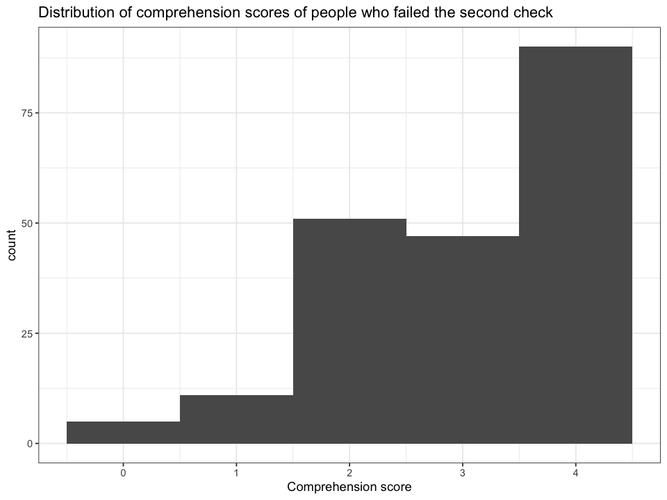

```r
comprehension_score <- function(response) {
    # +1 point for selecting the correct options
    score <- to_vec(for(opt in correct_comprehension_options) grepl(opt, response, fixed=TRUE)) %>% sum()
    # +1 point for not selecting the incorrect option
    score + !grepl(incorrect_comprehension_option, response, fixed=TRUE)
}

excluded_participants <- df %>% filter(comprehension_performance == 'fail second check')

excluded_participants %>%
    mutate(comprehension_score = mapply(comprehension_score, `attention_check_2`)) %>%
    ggplot(aes(x = comprehension_score)) + geom_histogram(bins = 5) +
    labs(title = sprintf("Distribution of comprehension scores of people who failed the second check"), x = "Comprehension score")
```

We also look at how many people failed the second check because they selected the incorrect option:

```r
excluded_participants %>%
    filter(grepl(incorrect_comprehension_option, `attention_check_2`, fixed=TRUE)) %>%
    select(ResponseId) %>% nrow()
```

58

Finally, we exclude participants who failed the second comprehension check.

```r
excluded_participants <- excluded_participants %>% select(ResponseId)

df <- df %>%
    anti_join(excluded_participants)

df_long <- df_long %>%
    anti_join(excluded_participants)


nrow(df)
```

1091

### Remove suspicious numeric responses

We then identify the participants who answered the trap question precisely.

```r
trapped_response_ids <- df_long %>%
    filter(question_type == "recall" & question == "trap_1" & is_identical_recall) %>%
    distinct(ResponseId)
nrow(trapped_response_ids)
```

44

From now, we will exclude these trapped participants

```r
df <- df %>%
    anti_join(trapped_response_ids)


df_long <- df_long %>%
    anti_join(trapped_response_ids)
```

```r
nrow(df)
```

1047

So our final sample consists of 1047 participants.

## Sanity checks

### Randomization check

```r
df %>% count(condition)
```

A tibble: 2 × 2

| condition <chr> | n <int> |
| --- | --- |
| Precise | 547 |
| Round | 500 |

### Time spent on the experiment

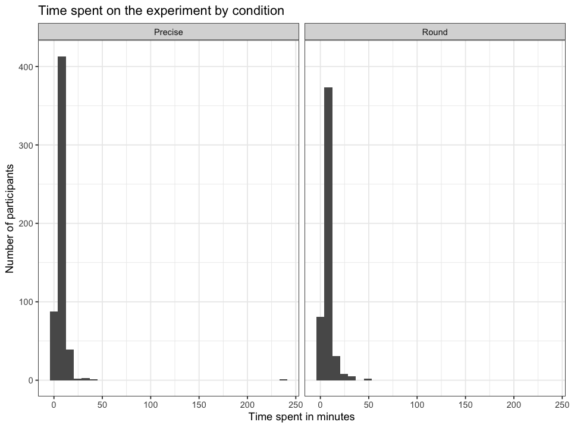

```r
ggplot(df, aes(x = duration/60)) +
  geom_histogram() +
  facet_wrap(~ condition) +
  labs(x = "Time spent in minutes",
       y = "Number of participants",
       title = "Time spent on the experiment by condition")
```

```r
df %>% group_by(condition) %>% summarize(median_time = median(duration/60))
```

A tibble: 2 × 2

| condition <chr> | median_time <dbl> |
| --- | --- |
| Precise | 6.283333 |
| Round | 5.850000 |

The median time to complete the experiment was ~6 minutes.

## Recall

### Public college enrollment

```r
# general function to construct a histogram of responses ranges in each condition
plot_responses_by_condition <- function(qtype, qid, x_label, title, scale_log10 = TRUE) {
    exact_value <- filter(exact_values, qtype == question_type & question == qid)$actual_exact[1]
    data_col <- sprintf("%s_%s", qtype, qid)
    histogram <- ggplot(df, aes(x = !!sym(data_col))) +
        geom_histogram() +
        geom_vline(xintercept = exact_value, linetype = 'dashed', color = 'red') +
        facet_wrap(~ condition, ncol = 1, scale = "free_y") +
        labs(
            x = x_label,
            y = "Number of responses",
            title = title,
            subtitle = sprintf('Actual was %s', as.character(exact_value))
        )
    if (scale_log10) {
        histogram + scale_x_log10(label = comma)
    } else {
        histogram
    }
}

# general function to compute the percentage of responses that are within 10% of the exact value
compute_correct_percentages <- function(data_col, exact_value, margin) {
    df %>%
      mutate(approx_correct = !!sym(data_col) >= (1 - margin)*exact_value &
             !!sym(data_col) <= (1 + margin)*exact_value) %>%
      group_by(condition) %>%
      summarize(count = n(),
                frac_approx_correct = mean(approx_correct),
                se = sqrt(frac_approx_correct * (1 - frac_approx_correct) / n()),
                lower = frac_approx_correct - se,
                upper = frac_approx_correct + se)
}

# general function to construct an error bar of correct response percentages in each condition
plot_correct_pct_by_condition <- function(qtype, qid, title) {
    exact_value <- filter(exact_values, question_type == qtype & question == qid)$actual_exact[1]
    data_col <- sprintf("%s_%s", qtype, qid)
    plot_data <- compute_correct_percentages(data_col, exact_value, margin)

    ggplot(plot_data, aes(x = condition, y = frac_approx_correct)) +
    geom_pointrange(aes(ymin = lower, ymax = upper)) +
    scale_y_continuous(label = percent) +
    labs(
        x = '',
        y = sprintf('Percent of approximately correct responses\n(within %d%% of exact answer)', margin * 100),
        title = title
    )
}

# general function to display all distinct responses and their frequencies in each condition
distinct_responses_by_condition <- function(qtype, qid) {
    actual_exact <- filter(exact_values, question_type == qtype & question == qid)$actual_exact[1]
    actual_approx <- filter(exact_values, question_type == qtype & question == qid)$actual_approx[1]
    condition_sizes <- (df %>% count(condition) %>% arrange(condition) %>% select(n))[[1]]
    print(sprintf(
        "Actual value was %s in the precise condition and %s in the round condition",
        as.character(actual_exact), as.character(actual_approx)
    ))
    table_data <- df_long %>%
        filter(question_type == qtype & question == qid) %>%
        group_by(response, condition) %>%
        summarize(count = n(), correctness = prod(is_correct_exact)) %>%
        pivot_wider(names_from = "condition", values_from = "count", names_prefix = "Frequency in ") %>%
        mutate(`Frequency in Precise` = coalesce(`Frequency in Precise`, 0),
               `Frequency in Round` = coalesce(`Frequency in Round`, 0)) %>%
        select(response, correctness, `Frequency in Precise`, `Frequency in Round`)

    colnames(table_data) <- c('response', 'correctness',
                              sprintf('Frequency in Precise (n = %d)', condition_sizes[1]),
                              sprintf('Frequency in Round (n = %d)', condition_sizes[2]))

    table_data %>% arrange(desc(correctness), desc(response))
}

remove_outliers <- function(df, iqr_factor, colname = "response") {
    Q <- quantile(df[[colname]], probs=c(.25, .75), na.rm = TRUE)
    iqr <- IQR(df[[colname]])
    up <- Q[2] + iqr_factor*iqr
    low <- Q[1] - iqr_factor*iqr
    df %>% filter(df[[colname]] > low & df[[colname]] < up)
}

text_setting <- function(){
    theme(
        axis.title.y = element_text(size = 16),
        axis.text.y = element_text(size = 16),
        axis.text.x = element_text(size = 16),
        strip.text.x = element_text(size = 18),
        text = element_text(size = 14)
    )
}
```

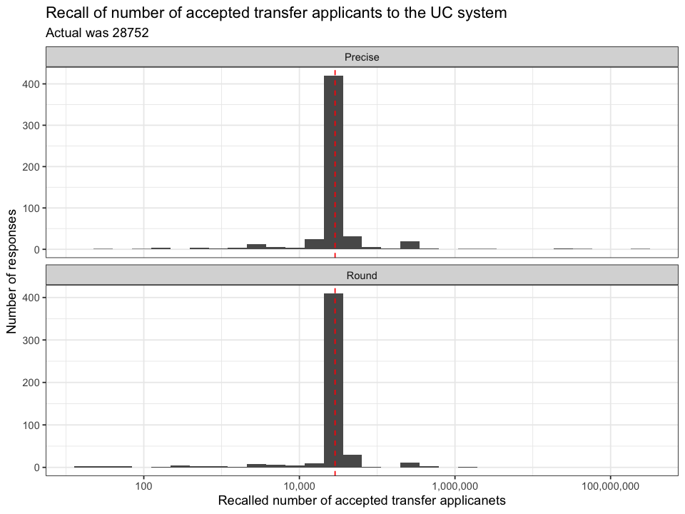

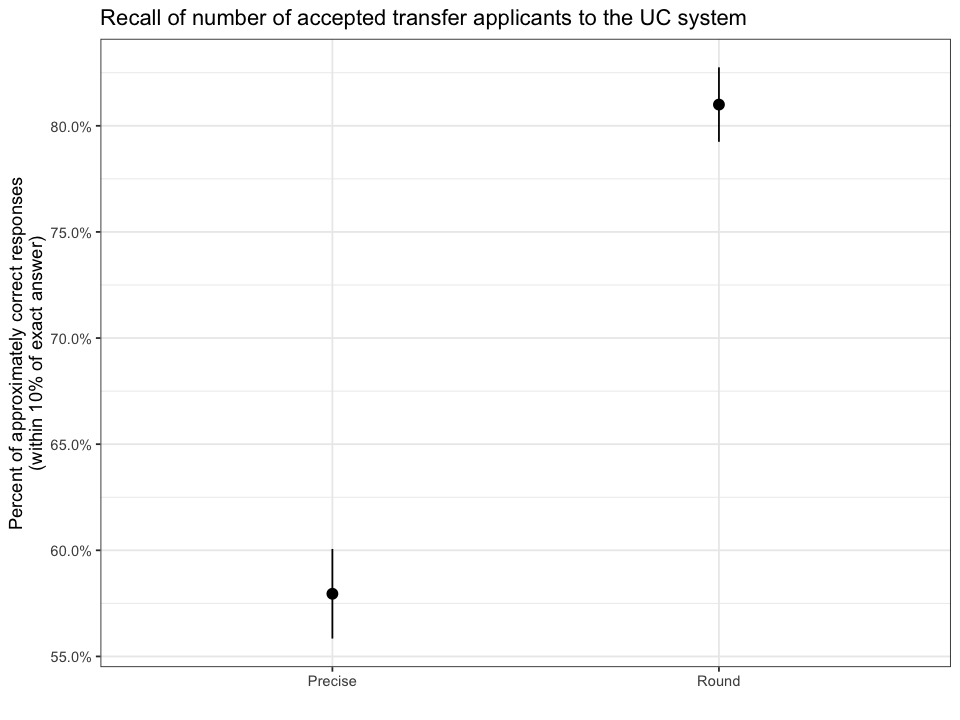

```r
plot_responses_by_condition(
    "recall", "enroll_1",
    "Recalled number of accepted transfer applicanets",
    "Recall of number of accepted transfer applicants to the UC system"
)

plot_correct_pct_by_condition(
    "recall", "enroll_1",
    "Recall of number of accepted transfer applicants to the UC system"
)
```

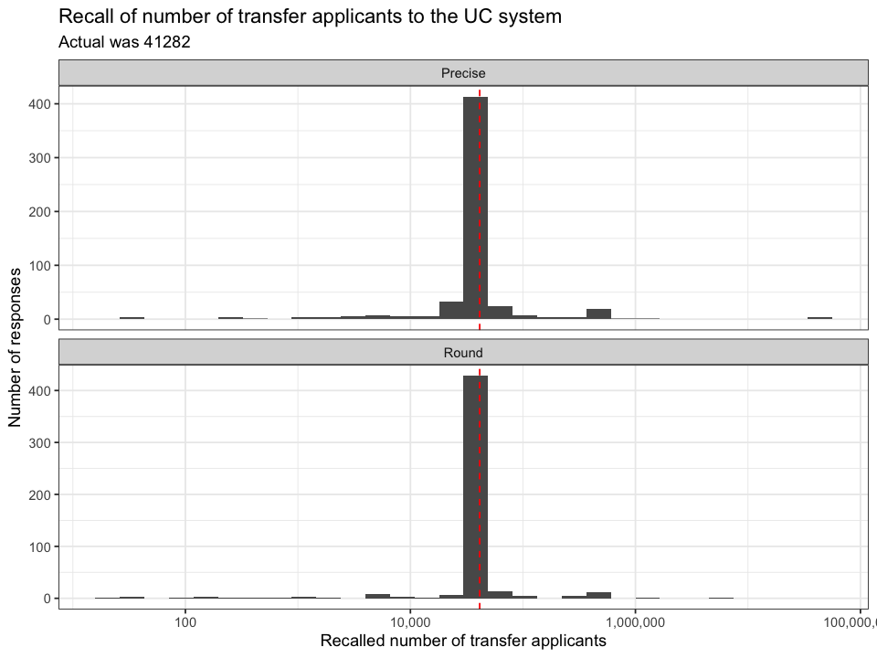

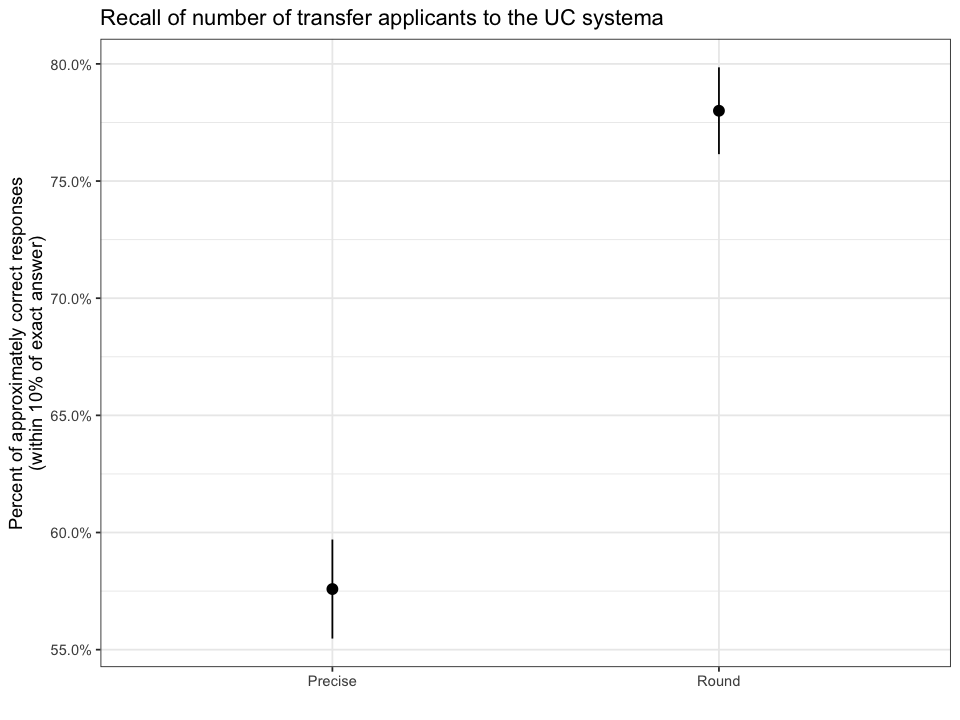

```r
plot_responses_by_condition(
    "recall", "enroll_2",
    "Recalled number of transfer applicants",
    "Recall of number of transfer applicants to the UC system"
)

plot_correct_pct_by_condition(
    "recall", "enroll_2",
    "Recall of number of transfer applicants to the UC systema"
)
```

### Honduran immigrants

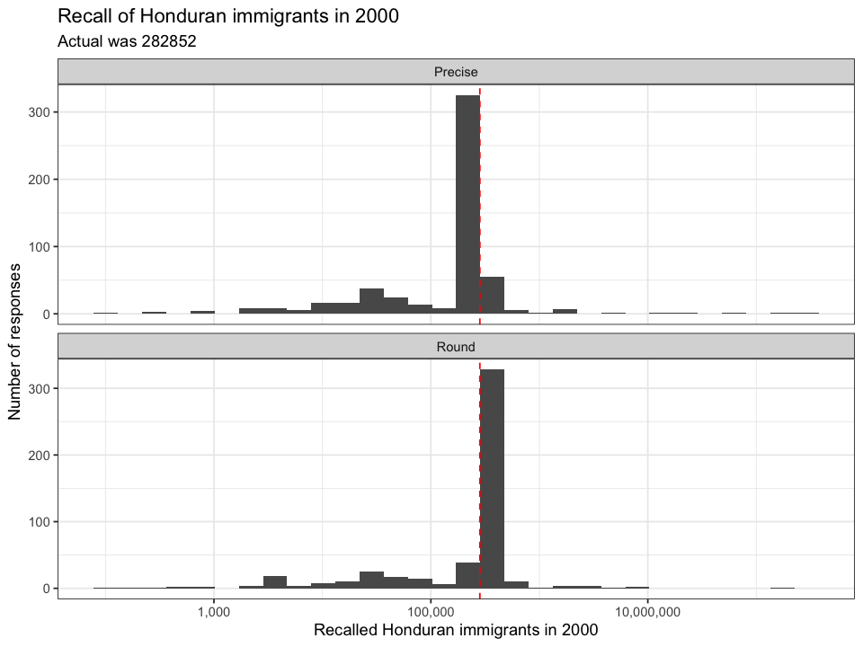

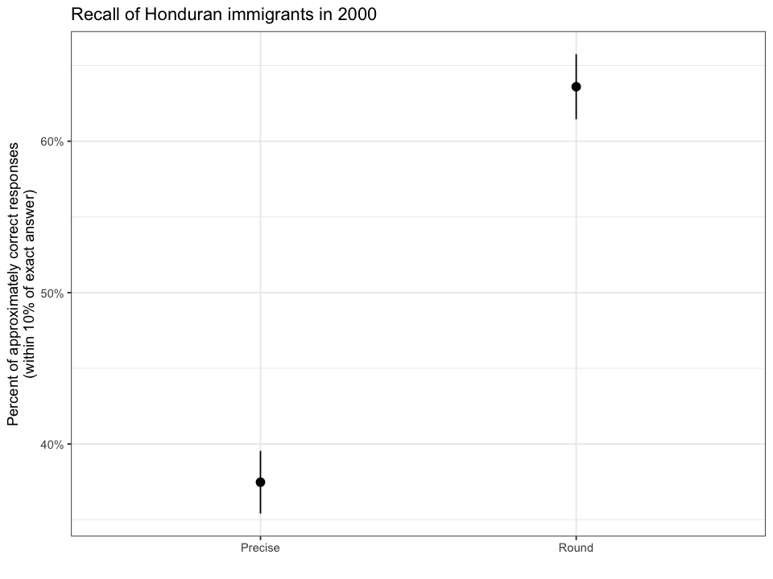

```r
plot_responses_by_condition(
    "recall", "hondura_1",
    "Recalled Honduran immigrants in 2000",
    "Recall of Honduran immigrants in 2000"
)

plot_correct_pct_by_condition(
    "recall", "hondura_1",
    "Recall of Honduran immigrants in 2000"
)
```

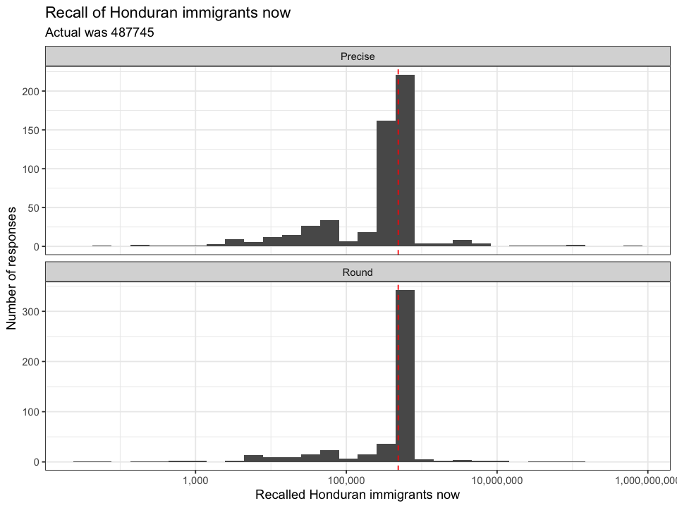

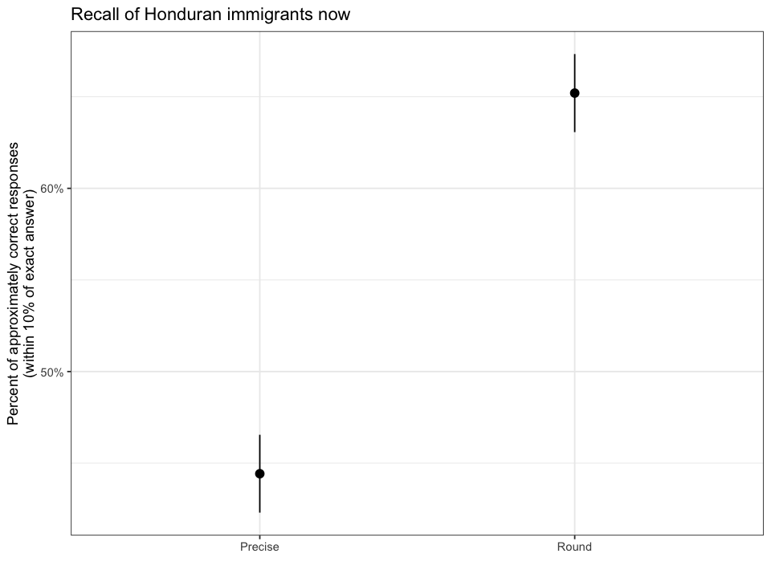

```r
plot_responses_by_condition(
    "recall", "hondura_2",
    "Recalled Honduran immigrants now",
    "Recall of Honduran immigrants now"
)

plot_correct_pct_by_condition(
    "recall", "hondura_2",
    "Recall of Honduran immigrants now"
)
```

### Museum size

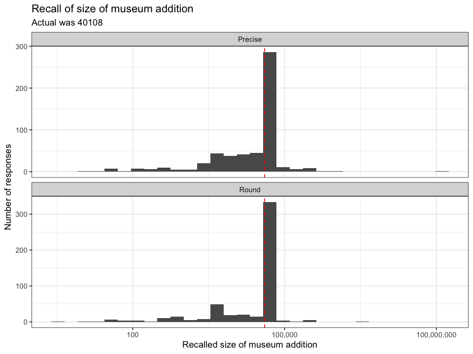

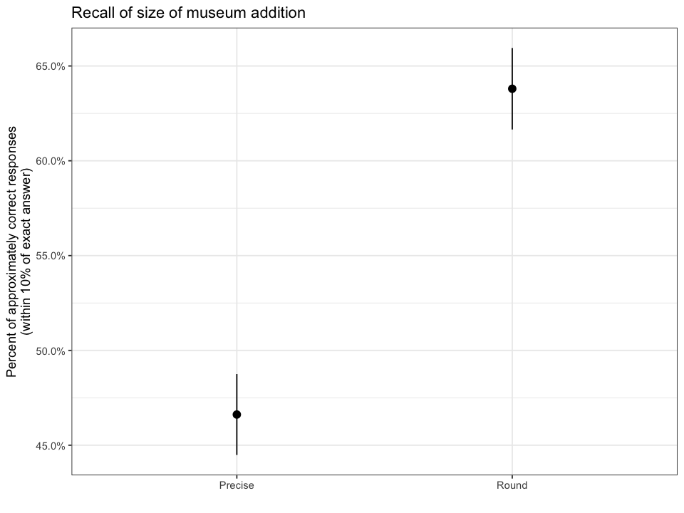

```r
plot_responses_by_condition(
    "recall", "frick_1",
    "Recalled size of museum addition",
    "Recall of size of museum addition"
)

plot_correct_pct_by_condition(
    "recall", "frick_1",
    "Recall of size of museum addition"
)
```

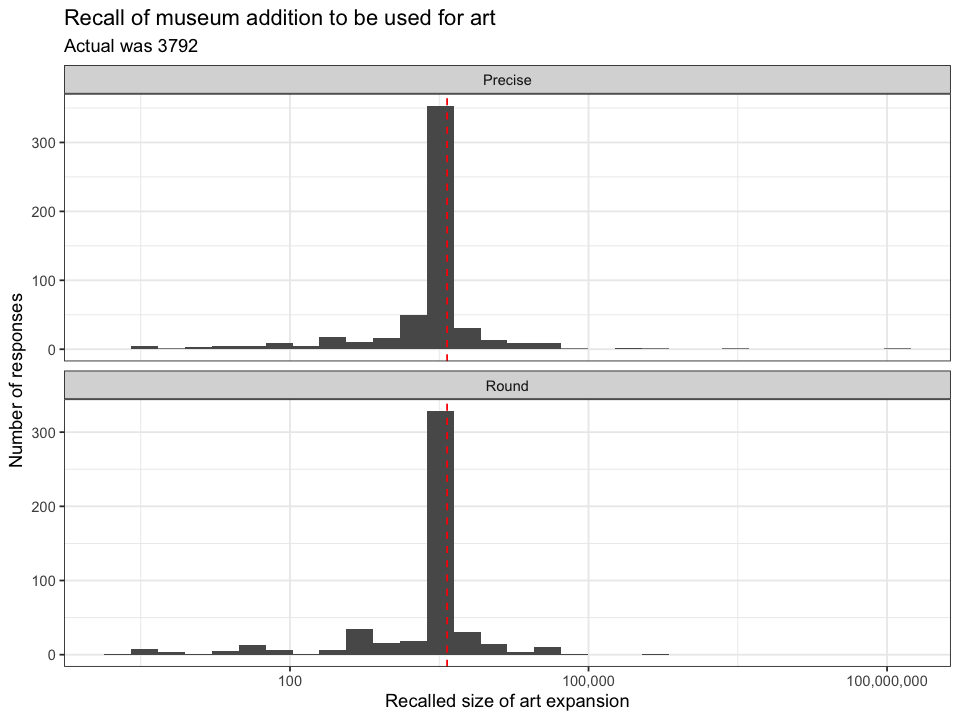

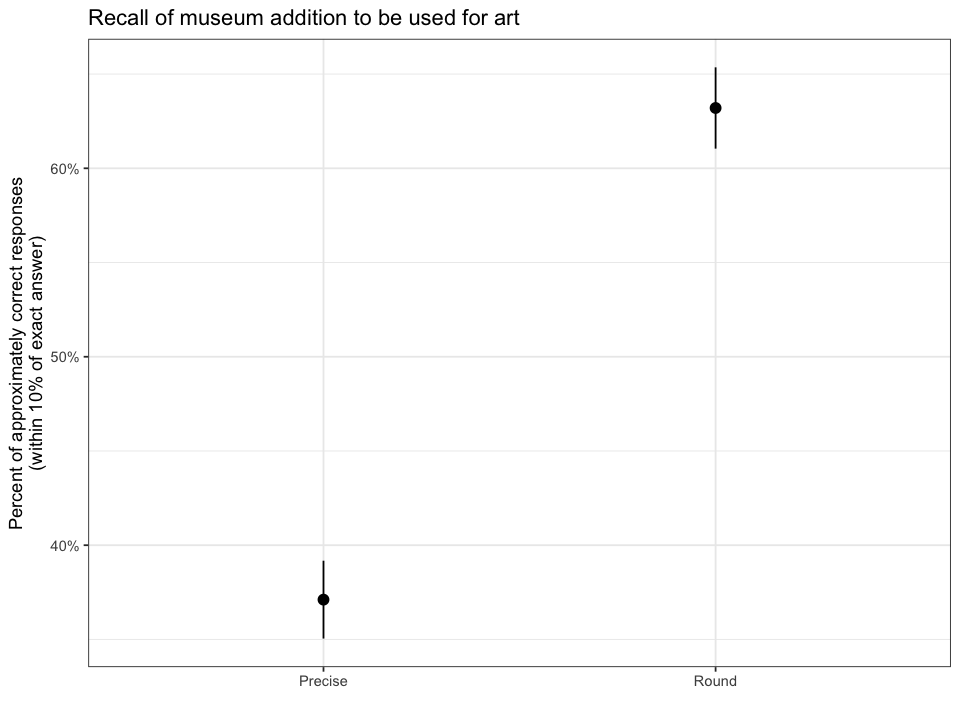

```r
plot_responses_by_condition(
    "recall", "frick_2",
    "Recalled size of art expansion",
    "Recall of museum addition to be used for art"
)

plot_correct_pct_by_condition(
    "recall", "frick_2",
    "Recall of museum addition to be used for art"
)
```

### Aggregate figures

#### Approximately correct recall by question

| condition | question_type | question | question_pretty | count | frac_approx_correct | se | lower | upper |
| --- | --- | --- | --- | --- | --- | --- | --- | --- |
| Precise | recall | enroll_1 | Enrollment: number of accepted transfer applicants | 547 | 0.5795247 | 0.0211063 | 0.5584184 | 0.6006310 |
| Precise | recall | enroll_2 | Enrollment: number of transer applicants | 547 | 0.5758684 | 0.0211309 | 0.5547375 | 0.5969993 |
| Precise | recall | frick_1 | Museum: Size of addition | 547 | 0.4661792 | 0.0213295 | 0.4448497 | 0.4875087 |
| Precise | recall | frick_2 | Museum: Size of addition for art | 547 | 0.3711152 | 0.0206560 | 0.3504592 | 0.3917712 |
| Precise | recall | hondura_1 | Immigrants: Hondurans in the U.S. 2000 | 547 | 0.3747715 | 0.0206971 | 0.3540744 | 0.3954686 |
| Precise | recall | hondura_2 | Immigrants: Hondurans in the U.S. now | 547 | 0.4442413 | 0.0212451 | 0.4229962 | 0.4654864 |
| Round | recall | enroll_1 | Enrollment: number of accepted transfer applicants | 500 | 0.8100000 | 0.0175442 | 0.7924558 | 0.8275442 |
| Round | recall | enroll_2 | Enrollment: number of transer applicants | 500 | 0.7800000 | 0.0185257 | 0.7614743 | 0.7985257 |
| Round | recall | frick_1 | Museum: Size of addition | 500 | 0.6380000 | 0.0214921 | 0.6165079 | 0.6594921 |
| Round | recall | frick_2 | Museum: Size of addition for art | 500 | 0.6320000 | 0.0215674 | 0.6104326 | 0.6535674 |
| Round | recall | hondura_1 | Immigrants: Hondurans in the U.S. 2000 | 500 | 0.6360000 | 0.0215176 | 0.6144824 | 0.6575176 |
| Round | recall | hondura_2 | Immigrants: Hondurans in the U.S. now | 500 | 0.6520000 | 0.0213024 | 0.6306976 | 0.6733024 |

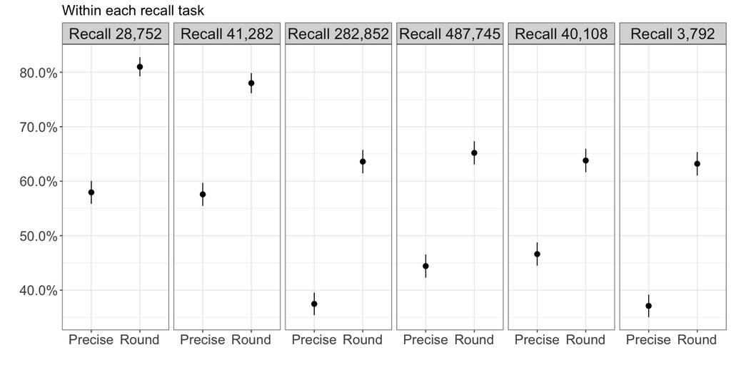

```r
plot_data <- df_long %>%
  filter(question_type == "recall" & question != 'trap_1') %>%
  group_by(condition, question_type, question, question_pretty) %>%
  summarize(count = n(),
            frac_approx_correct = mean(is_correct_exact),
            se = sqrt(frac_approx_correct * (1 - frac_approx_correct) / n()),
            lower = frac_approx_correct - se,
            upper = frac_approx_correct + se)

display_table(plot_data)

recall_facet_order <- to_vec(for(i in 2:7) sprintf("Recall %s", format(exact_values$actual_exact[i], big.mark = ",", trim = T)))

display_label_recall <- Vectorize(function(question) {
    current_labels <- c('enroll_1', 'enroll_2', 'hondura_1', 'hondura_2', 'frick_1', 'frick_2')
    display_labels <- exact_values$actual_exact
    recall_facet_order[which(current_labels == question)[1]]
})

options(repr.plot.width=12, repr.plot.height=6)

plot_data %>%
    mutate(question = question %>% display_label_recall() %>% factor(levels = recall_facet_order)) %>%
    ggplot(aes(x = condition, y = frac_approx_correct)) +
    geom_pointrange(aes(ymin = lower, ymax = upper)) +
    scale_y_continuous(label = percent) +
    facet_wrap(~question, nrow = 1) +
    text_setting() +
    labs(x = '',
       y = '',
       title = 'Within each recall task')
ggsave(filename = 'figures/recall_by_question.png', width = 12, height = 6)
```

#### Approximately correct recall across all questions

| condition | question_type | count | frac_approx_correct | se | lower | upper |
| --- | --- | --- | --- | --- | --- | --- |
| Precise | recall | 3282 | 0.4686167 | 0.0087105 | 0.4599062 | 0.4773272 |
| Round | recall | 3000 | 0.6913333 | 0.0084339 | 0.6828994 | 0.6997672 |

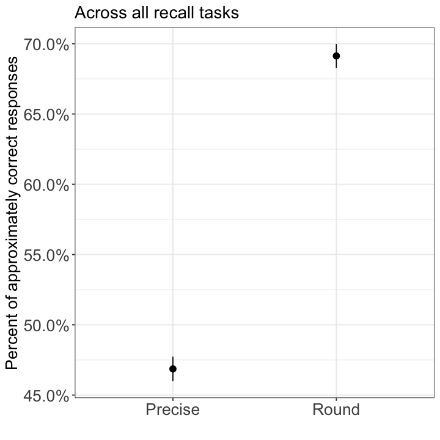

```r
plot_data <- df_long %>%
  filter(question_type == "recall" & question != 'trap_1') %>%
  group_by(condition, question_type) %>%
  summarize(count = n(),
            frac_approx_correct = mean(is_correct_exact),
            se = sqrt(frac_approx_correct * (1 - frac_approx_correct) / n()),
            lower = frac_approx_correct - se,
            upper = frac_approx_correct + se)

display_table(plot_data)

options(repr.plot.width=6, repr.plot.height=6)

plot_data %>%
    ggplot(aes(x = condition, y = frac_approx_correct)) +
    geom_pointrange(aes(ymin = lower, ymax = upper)) +
    scale_y_continuous(label = percent) +
    text_setting() +
    labs(x = '', y = 'Percent of approximately correct responses', title = 'Across all recall tasks')
ggsave(filename = 'figures/recall_all_questions.png')
```

#### Recall error categories across questions

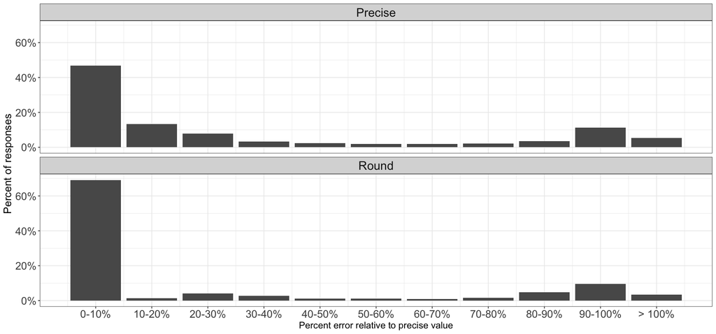

```r
options(repr.plot.width=15, repr.plot.height=7)

labels <- c("0-10%", "10-20%", "20-30%", "30-40%", "40-50%", "50-60%", "60-70%", "70-80%", "80-90%", "90-100%", "> 100%")
df_error <- df_long %>%
    filter(question_type == 'recall' & question != 'trap_1' ) %>%
    mutate(correct_order_mag = floor(log10(response)) == floor(log10(actual_exact)),
           percent_err = abs(response - actual_exact) / actual_exact,
           rounded_percent_err = floor(percent_err * 100 / 10) * 10,
           rounded_percent_err = ifelse(rounded_percent_err >= 100, 100, rounded_percent_err))

plot_data <- df_error %>%
    group_by(condition) %>%
    count(rounded_percent_err) %>%
    group_by(condition) %>%
    mutate(frac_of_responses = n / sum(n))

ggplot(plot_data, aes(x = rounded_percent_err, y = frac_of_responses)) +
    geom_bar(stat = "identity", position = "identity") +
    scale_x_continuous(breaks = seq(0,100,by=10), labels = labels) +
    scale_y_continuous(label = percent) +
    facet_wrap(~ condition, ncol = 1) +
    text_setting() +
    labs(x = "Percent error relative to precise value", y = "Percent of responses")
ggsave(filename = 'figures/recall_percent_error.png', width = 15, height = 7)
```

We further examined the responses corresponding to the bump in frequency at the 90-100% relative error bin, to see whether those are underestimates or overestimates of the true value.

```r
df_error%>%
    filter(rounded_percent_err >= 90 & rounded_percent_err < 100) %>%
    select(question, actual_exact, response, rounded_percent_err)
```

A tibble: 658 × 4

| question <chr> | actual_exact <dbl> | response <dbl> | rounded_percent_err <dbl> |
| --- | --- | --- | --- |
| hondura_1 | 282852 | 28000 | 90 |
| hondura_2 | 487745 | 41000 | 90 |
| frick_1 | 40108 | 4000 | 90 |
| hondura_1 | 282852 | 4000 | 90 |
| hondura_2 | 487745 | 7000 | 90 |
| frick_1 | 40108 | 4000 | 90 |
| frick_2 | 3792 | 4 | 90 |
| frick_1 | 40108 | 30 | 90 |
| frick_2 | 3792 | 20 | 90 |
| hondura_2 | 487745 | 8500 | 90 |
| frick_1 | 40108 | 40 | 90 |
| frick_2 | 3792 | 4 | 90 |
| hondura_1 | 282852 | 5000 | 90 |
| hondura_2 | 487745 | 12000 | 90 |
| hondura_1 | 282852 | 10000 | 90 |
| hondura_2 | 487745 | 20000 | 90 |
| frick_1 | 40108 | 400 | 90 |
| hondura_2 | 487745 | 4000 | 90 |
| frick_1 | 40108 | 1000 | 90 |
| hondura_1 | 282852 | 26000 | 90 |
| hondura_2 | 487745 | 45000 | 90 |
| hondura_2 | 487745 | 20000 | 90 |
| frick_1 | 40108 | 4000 | 90 |
| frick_2 | 3792 | 40 | 90 |
| hondura_1 | 282852 | 20000 | 90 |
| hondura_2 | 487745 | 40000 | 90 |
| frick_2 | 3792 | 50 | 90 |
| frick_1 | 40108 | 4000 | 90 |
| hondura_1 | 282852 | 20000 | 90 |
| hondura_2 | 487745 | 30000 | 90 |
| ⋮ | ⋮ | ⋮ | ⋮ |
| frick_2 | 3792 | 100 | 90 |
| frick_1 | 40108 | 4000 | 90 |
| enroll_1 | 28752 | 200 | 90 |
| enroll_2 | 41282 | 1000 | 90 |
| hondura_1 | 282852 | 20000 | 90 |
| frick_1 | 40108 | 50 | 90 |
| frick_2 | 3792 | 100 | 90 |
| hondura_1 | 282852 | 20000 | 90 |
| hondura_2 | 487745 | 30000 | 90 |
| enroll_1 | 28752 | 2000 | 90 |
| enroll_2 | 41282 | 3000 | 90 |
| hondura_1 | 282852 | 5000 | 90 |
| hondura_2 | 487745 | 1000 | 90 |
| frick_1 | 40108 | 2500 | 90 |
| frick_1 | 40108 | 1600 | 90 |
| frick_2 | 3792 | 40 | 90 |
| hondura_1 | 282852 | 23000 | 90 |
| hondura_2 | 487745 | 13000 | 90 |
| hondura_2 | 487745 | 20000 | 90 |
| frick_1 | 40108 | 500 | 90 |
| frick_2 | 3792 | 200 | 90 |
| frick_1 | 40108 | 4000 | 90 |
| frick_2 | 3792 | 7 | 90 |
| enroll_1 | 28752 | 800 | 90 |
| enroll_2 | 41282 | 2500 | 90 |
| hondura_1 | 282852 | 1000 | 90 |
| hondura_2 | 487745 | 2500 | 90 |
| frick_1 | 40108 | 500 | 90 |
| frick_2 | 3792 | 250 | 90 |
| frick_1 | 40108 | 3000 | 90 |

```r
df_error%>%
    filter(rounded_percent_err == 100) %>%
    select(question, actual_exact, response, rounded_percent_err)
```

A tibble: 280 × 4

| question <chr> | actual_exact <dbl> | response <dbl> | rounded_percent_err <dbl> |
| --- | --- | --- | --- |
| frick_2 | 3792 | 20000 | 100 |
| enroll_1 | 28752 | 240000 | 100 |
| hondura_2 | 487745 | 4100000 | 100 |
| frick_1 | 40108 | 400000 | 100 |
| hondura_1 | 282852 | 2000000 | 100 |
| hondura_2 | 487745 | 10000000 | 100 |
| frick_2 | 3792 | 37000 | 100 |
| enroll_1 | 28752 | 400000 | 100 |
| enroll_2 | 41282 | 300000 | 100 |
| frick_2 | 3792 | 10000 | 100 |
| frick_1 | 40108 | 400000 | 100 |
| enroll_1 | 28752 | 284791 | 100 |
| frick_2 | 3792 | 39473 | 100 |
| frick_1 | 40108 | 400000 | 100 |
| frick_2 | 3792 | 40000 | 100 |
| hondura_2 | 487745 | 40000000 | 100 |
| frick_1 | 40108 | 292000 | 100 |
| frick_2 | 3792 | 15000 | 100 |
| frick_2 | 3792 | 40000 | 100 |
| enroll_1 | 28752 | 1342576 | 100 |
| enroll_2 | 41282 | 1200000 | 100 |
| hondura_1 | 282852 | 681000 | 100 |
| hondura_1 | 282852 | 1435564 | 100 |
| frick_2 | 3792 | 35324 | 100 |
| enroll_1 | 28752 | 252789 | 100 |
| enroll_2 | 41282 | 452673 | 100 |
| frick_1 | 40108 | 90000 | 100 |
| enroll_1 | 28752 | 250000 | 100 |
| enroll_2 | 41282 | 419000 | 100 |
| frick_2 | 3792 | 30000 | 100 |
| ⋮ | ⋮ | ⋮ | ⋮ |
| enroll_1 | 28752 | 70000 | 100 |
| enroll_2 | 41282 | 6000018 | 100 |
| enroll_2 | 41282 | 471000 | 100 |
| hondura_2 | 487745 | 4790004 | 100 |
| hondura_1 | 282852 | 3000000 | 100 |
| hondura_2 | 487745 | 2000000 | 100 |
| enroll_1 | 28752 | 200000 | 100 |
| enroll_2 | 41282 | 400000 | 100 |
| hondura_1 | 282852 | 2180000 | 100 |
| hondura_2 | 487745 | 4000000 | 100 |
| enroll_1 | 28752 | 300000 | 100 |
| enroll_2 | 41282 | 400000 | 100 |
| enroll_1 | 28752 | 200000 | 100 |
| enroll_2 | 41282 | 150000 | 100 |
| frick_2 | 3792 | 20000 | 100 |
| frick_1 | 40108 | 4000000 | 100 |
| frick_1 | 40108 | 150000 | 100 |
| enroll_1 | 28752 | 100000 | 100 |
| enroll_2 | 41282 | 200000 | 100 |
| frick_1 | 40108 | 400000 | 100 |
| enroll_2 | 41282 | 341750 | 100 |
| enroll_2 | 41282 | 100000 | 100 |
| enroll_1 | 28752 | 65000 | 100 |
| enroll_1 | 28752 | 300000 | 100 |
| enroll_2 | 41282 | 400000 | 100 |
| hondura_1 | 282852 | 1000000 | 100 |
| hondura_2 | 487745 | 2000000 | 100 |
| frick_2 | 3792 | 12099 | 100 |
| frick_1 | 40108 | 140000 | 100 |
| enroll_2 | 41282 | 400000 | 100 |

## Calculate

### Public college enrollment

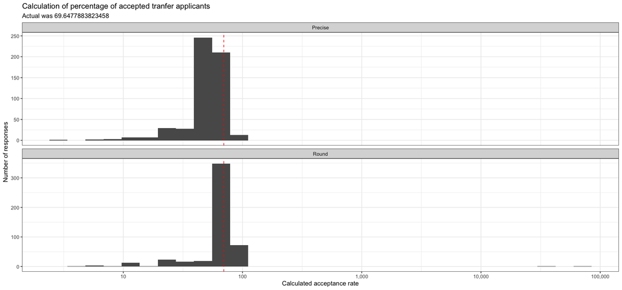

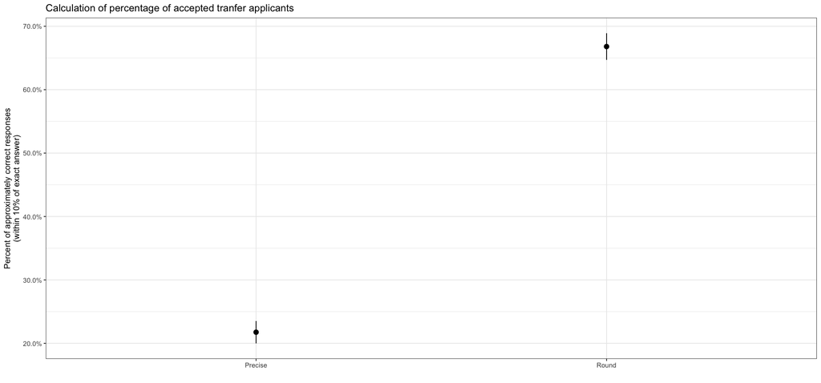

```r
plot_responses_by_condition(
    "calculate", "enroll",
    "Calculated acceptance rate",
    "Calculation of percentage of accepted tranfer applicants"
)

plot_correct_pct_by_condition(
    "calculate", "enroll",
    "Calculation of percentage of accepted tranfer applicants"
)
```

### Honduran immigrants

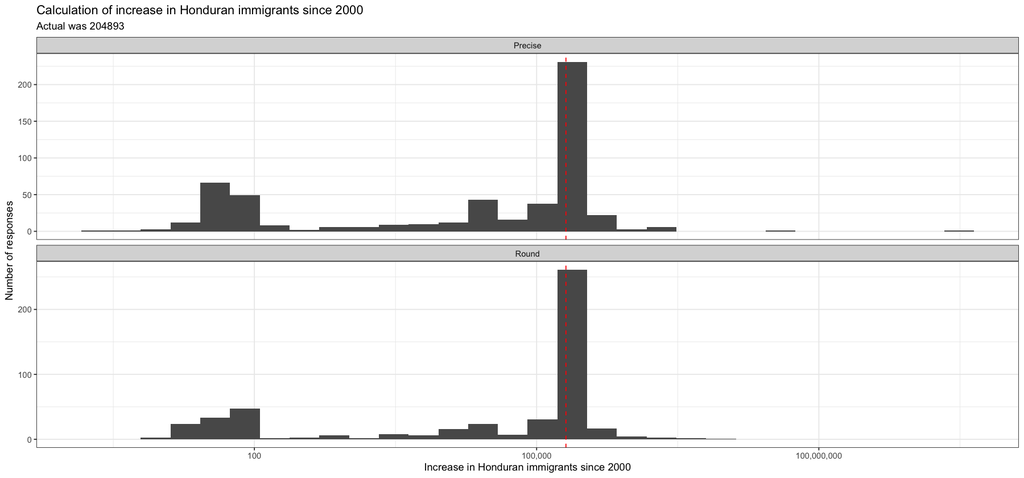

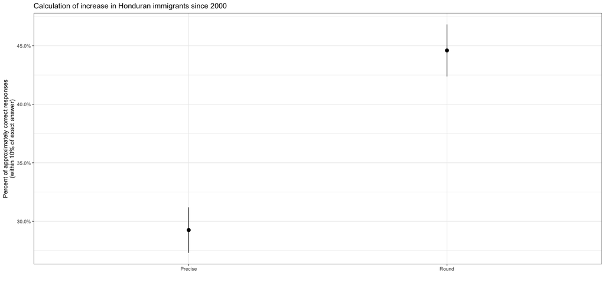

```r
plot_responses_by_condition(
    "calculate", "hondura",
    "Increase in Honduran immigrants since 2000",
    "Calculation of increase in Honduran immigrants since 2000"
)

plot_correct_pct_by_condition(
    "calculate", "hondura",
    "Calculation of increase in Honduran immigrants since 2000"
)
```

### Museum size

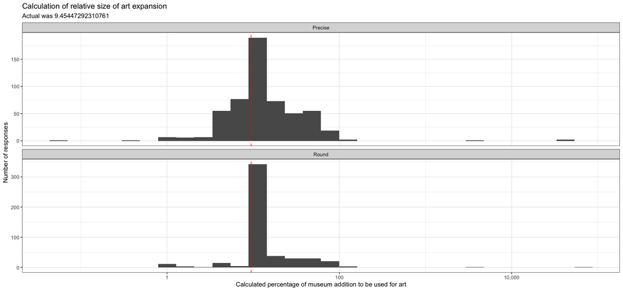

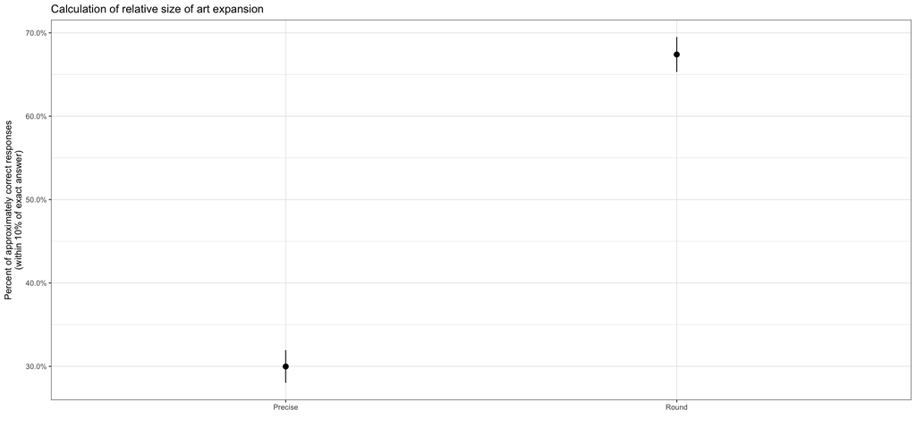

```r
plot_responses_by_condition(
    "calculate", "frick",
    "Calculated percentage of museum addition to be used for art",
    "Calculation of relative size of art expansion"
)

plot_correct_pct_by_condition(
    "calculate", "frick",
    "Calculation of relative size of art expansion"
)
```

### Aggregate figures

#### Approximately correct calculations by condition

| condition | question_type | question | question_pretty | count | frac_approx_correct | se | lower | upper |
| --- | --- | --- | --- | --- | --- | --- | --- | --- |
| Precise | calculate | enroll | Enrollment: percentage of accepted transfer applicaents | 547 | 0.2175503 | 0.0176406 | 0.1999096 | 0.2351909 |
| Round | calculate | enroll | Enrollment: percentage of accepted transfer applicaents | 500 | 0.6680000 | 0.0210607 | 0.6469393 | 0.6890607 |
| Precise | calculate | frick | Museum: Percentage of addition for art | 547 | 0.2998172 | 0.0195903 | 0.2802269 | 0.3194075 |
| Round | calculate | frick | Museum: Percentage of addition for art | 500 | 0.6740000 | 0.0209630 | 0.6530370 | 0.6949630 |
| Precise | calculate | hondura | Immigrants: Increase in Hondurans in the U.S. since 2000 | 547 | 0.2925046 | 0.0194507 | 0.2730539 | 0.3119552 |
| Round | calculate | hondura | Immigrants: Increase in Hondurans in the U.S. since 2000 | 500 | 0.4460000 | 0.0222299 | 0.4237701 | 0.4682299 |

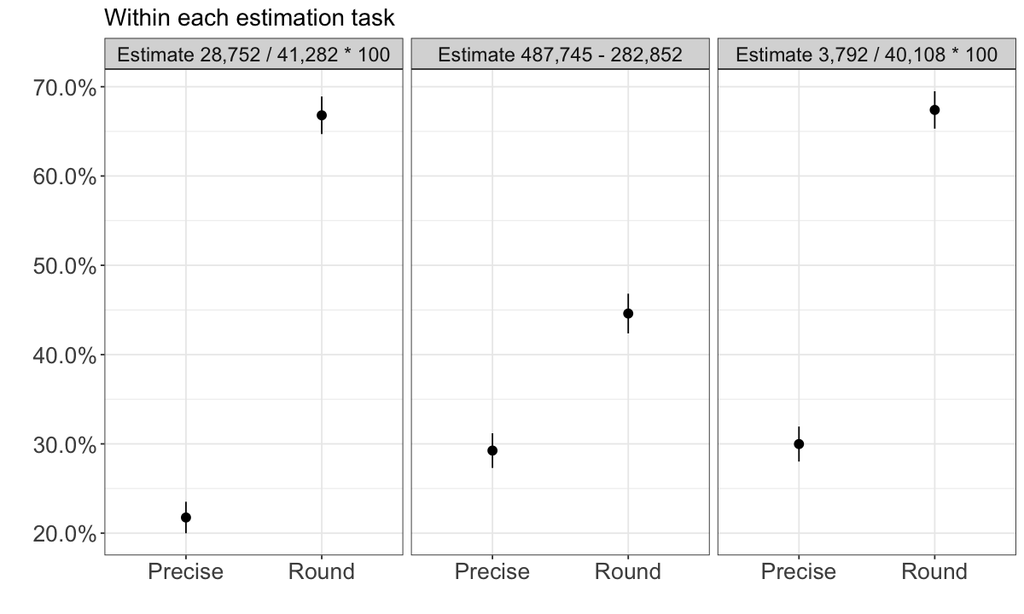

```r
plot_data <- df_long %>%
    filter(question_type == "calculate") %>%
    group_by(condition, question_type, question,question_pretty) %>%
    summarize(count = n(),
            frac_approx_correct = mean(is_correct_exact),
            se = sqrt(frac_approx_correct * (1 - frac_approx_correct) / n()),
            lower = frac_approx_correct - se,
            upper = frac_approx_correct + se)

plot_data %>% arrange(question, condition) %>% display_table()

calculate_facet_order <- c("Estimate 28,752 / 41,282 * 100", "Estimate 487,745 - 282,852", "Estimate 3,792 / 40,108 * 100")

display_label_calculate <- Vectorize(function(question) {
    current_labels <- c('enroll', 'hondura', 'frick')
    calculate_facet_order[which(current_labels == question)[1]]
})

options(repr.plot.width=10, repr.plot.height=6)
plot_data %>%
    mutate(question = question %>% display_label_calculate() %>% factor(levels = calculate_facet_order)) %>%
    ggplot(aes(x = condition, y = frac_approx_correct)) +
    geom_pointrange(aes(ymin = lower, ymax = upper)) +
    scale_y_continuous(label = percent) +
    facet_wrap(~question, nrow = 1) +
    text_setting() +
    theme(strip.text.x = element_text(size = 14)) +
    labs(x = '',
       y = '',
       title = 'Within each estimation task')
ggsave(filename = 'figures/estimate_by_question.png', width = 10, height = 6)
```

#### Approximately correct calculations across all questions

| condition | question_type | count | frac_approx_correct | se | lower | upper |
| --- | --- | --- | --- | --- | --- | --- |
| Precise | calculate | 1641 | 0.2699573 | 0.0109589 | 0.2589984 | 0.2809163 |
| Round | calculate | 1500 | 0.5960000 | 0.0126698 | 0.5833302 | 0.6086698 |

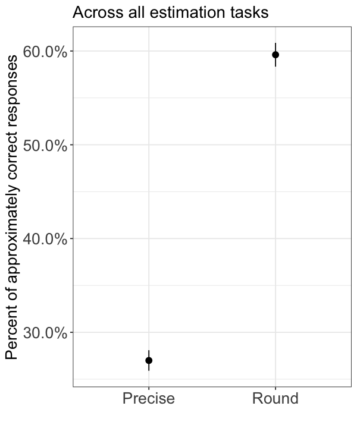

```r
plot_data <- df_long %>%
  filter(question_type == "calculate") %>%
  group_by(condition, question_type) %>%
  summarize(count = n(),
            frac_approx_correct = mean(is_correct_exact),
            se = sqrt(frac_approx_correct * (1 - frac_approx_correct) / n()),
            lower = frac_approx_correct - se,
            upper = frac_approx_correct + se)

display_table(plot_data)

options(repr.plot.width=5, repr.plot.height=6)

plot_data %>%
    ggplot(aes(x = condition, y = frac_approx_correct)) +
    geom_pointrange(aes(ymin = lower, ymax = upper)) +
    scale_y_continuous(label = percent) +
    text_setting() +
    labs(x = '',
       y = 'Percent of approximately correct responses',
       title = 'Across all estimation tasks')
ggsave(filename = 'figures/estimate_all_questions.png')
```

## Significance tests

### Each question separately

```r
df_long %>%
    group_by(question_type, question, question_pretty, condition) %>%
    summarize(n_total = n(), n_correct = sum(is_correct_exact)) %>%
    group_by(question_type, question, question_pretty) %>%
    do(tidy(prop.test(.$n_correct, .$n_total))) %>%
    display_table()
```

| question_type | question | question_pretty | estimate1 | estimate2 | statistic | p.value | parameter | conf.low | conf.high | method | alternative |
| --- | --- | --- | --- | --- | --- | --- | --- | --- | --- | --- | --- |
| calculate | enroll | Enrollment: percentage of accepted transfer applicaents | 0.2175503 | 0.668 | 214.0983386 | 0.0000000 | 1 | -0.5062091 | -0.3946903 | 2-sample test for equality of proportions with continuity correction | two.sided |
| calculate | frick | Museum: Percentage of addition for art | 0.2998172 | 0.674 | 145.0730625 | 0.0000000 | 1 | -0.4323320 | -0.3160336 | 2-sample test for equality of proportions with continuity correction | two.sided |
| calculate | hondura | Immigrants: Increase in Hondurans in the U.S. since 2000 | 0.2925046 | 0.446 | 25.8719234 | 0.0000004 | 1 | -0.2133030 | -0.0936878 | 2-sample test for equality of proportions with continuity correction | two.sided |
| recall | enroll_1 | Enrollment: number of accepted transfer applicants | 0.5795247 | 0.810 | 63.7512395 | 0.0000000 | 1 | -0.2861824 | -0.1747683 | 2-sample test for equality of proportions with continuity correction | two.sided |
| recall | enroll_2 | Enrollment: number of transer applicants | 0.5758684 | 0.780 | 48.5653451 | 0.0000000 | 1 | -0.2611244 | -0.1471389 | 2-sample test for equality of proportions with continuity correction | two.sided |
| recall | frick_1 | Museum: Size of addition | 0.4661792 | 0.638 | 30.4475475 | 0.0000000 | 1 | -0.2330820 | -0.1105597 | 2-sample test for equality of proportions with continuity correction | two.sided |
| recall | frick_2 | Museum: Size of addition for art | 0.3711152 | 0.632 | 70.0816244 | 0.0000000 | 1 | -0.3213301 | -0.2004396 | 2-sample test for equality of proportions with continuity correction | two.sided |
| recall | hondura_1 | Immigrants: Hondurans in the U.S. 2000 | 0.3747715 | 0.636 | 70.2626373 | 0.0000000 | 1 | -0.3216592 | -0.2007979 | 2-sample test for equality of proportions with continuity correction | two.sided |
| recall | hondura_2 | Immigrants: Hondurans in the U.S. now | 0.4442413 | 0.652 | 44.6110901 | 0.0000000 | 1 | -0.2686396 | -0.1468778 | 2-sample test for equality of proportions with continuity correction | two.sided |
| recall | trap_1 | Trap: California population | 0.6160878 | 0.598 | 0.2865646 | 0.5924305 | 1 | -0.0430547 | 0.0792302 | 2-sample test for equality of proportions with continuity correction | two.sided |

### By question type (recall / calculation / estimation)

Note that here we treat responses as independent, but repeated measures analysis is better.

```r
df_long %>%
  group_by(question_type, condition) %>%
  summarize(n_total = n(), n_correct = sum(is_correct_exact)) %>%
  group_by(question_type) %>%
  do(tidy(prop.test(.$n_correct, .$n_total))) %>%
  display_table()
```

| question_type | estimate1 | estimate2 | statistic | p.value | parameter | conf.low | conf.high | method | alternative |
| --- | --- | --- | --- | --- | --- | --- | --- | --- | --- |
| calculate | 0.2699573 | 0.596 | 339.4277 | 0 | 1 | -0.3595135 | -0.2925718 | 2-sample test for equality of proportions with continuity correction | two.sided |
| recall | 0.4896840 | 0.678 | 265.3593 | 0 | 1 | -0.2107327 | -0.1658994 | 2-sample test for equality of proportions with continuity correction | two.sided |

## Time spent

```r
plot_time_spent_on_activity <- function(activity, trim_pct = 0) {
    time_col <- sprintf("duration_%s", activity)
    # histogram of time spent on recall page
    time_histogram <- ggplot(df, aes(x = !!sym(time_col) / 60)) +
        geom_histogram() +
        facet_wrap(~ condition, scale = "free_y") +
        labs(
            x = sprintf("Time spent on %s page in minutes", activity),
            y = "Number of participants",
            title = sprintf("Time spent on %s", activity))
    print(time_histogram)

    # bar plot of mean & sd of time spent
    time_barplot <- df %>%
        group_by(condition) %>%
        summarize(count = n(),
            mean_time_recall_page = mean(!!sym(time_col)/60, trim = trim_pct),
            se = sd(!!sym(time_col)/60) / sqrt(n()),
            lower = mean_time_recall_page - se,
            upper = mean_time_recall_page + se) %>%
        ggplot(aes(x = condition, y = mean_time_recall_page)) +
        geom_pointrange(aes(ymin = lower, ymax = upper)) +
        labs(
            x = "",
            y = sprintf("Average time spent on %s page", activity),
            title = sprintf("Time spent on %s by condition", activity),
            subtitle = "Trimmed 2.5% of outliers on upper and lower ends")
    print(time_barplot)
}
```

### Time spent on recall

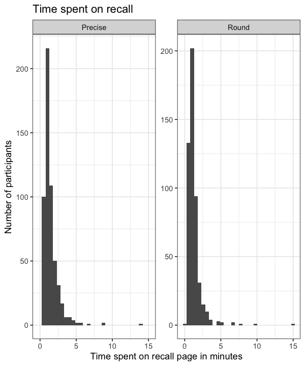

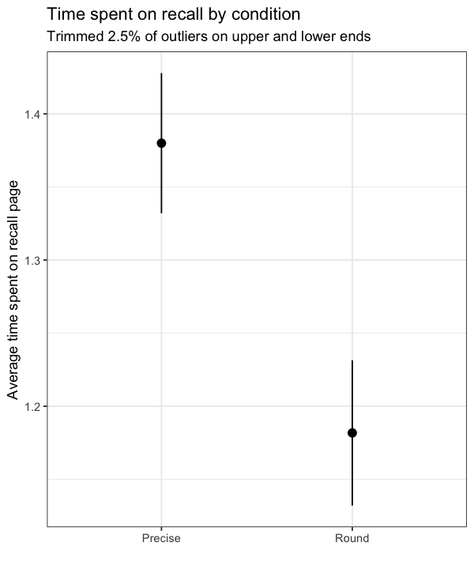

```r
plot_time_spent_on_activity("recall", 0.025)
```

```r
df %>% group_by(condition) %>% summarize(median_recall = median(duration_recall)) %>% display_table()
wilcox.test(duration_recall ~ condition, data = df)
```

| condition | median_recall |
| --- | --- |
| Precise | 70.136 |
| Round | 61.950 |

```
	Wilcoxon rank sum test with continuity correction

data:  duration_recall by condition
W = 157500, p-value = 2.181e-05
alternative hypothesis: true location shift is not equal to 0
```

### Time spent on calculation

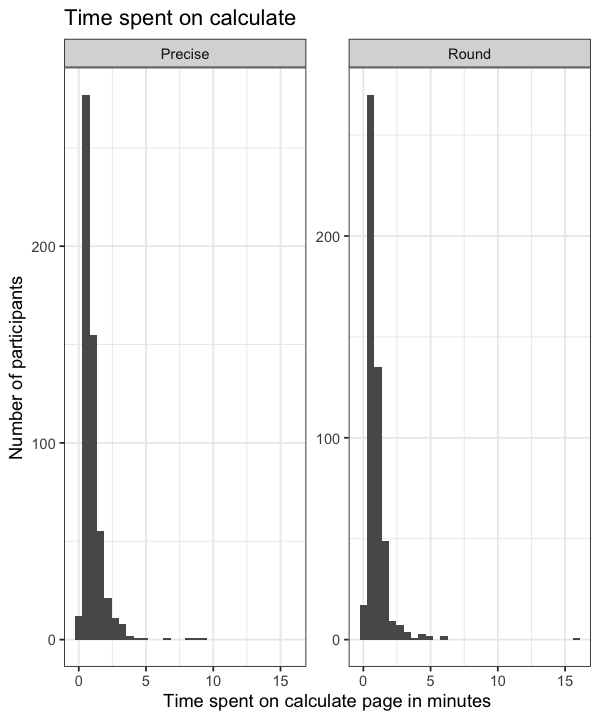

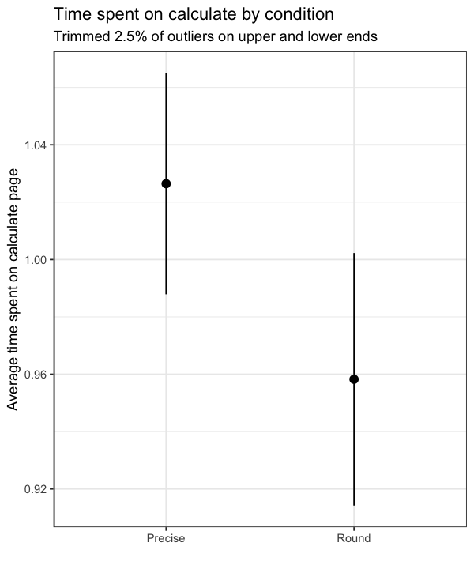

```r
plot_time_spent_on_activity("calculate")
```

```r
df %>% group_by(condition) %>% summarize(median_calculate = median(duration_calculate)) %>% display_table()
wilcox.test(duration_calculate ~ condition, data = df)
```

| condition | median_calculate |
| --- | --- |
| Precise | 47.215 |
| Round | 44.072 |

```
	Wilcoxon rank sum test with continuity correction

data:  duration_calculate by condition
W = 146407, p-value = 0.04817
alternative hypothesis: true location shift is not equal to 0
```

## Consistency between implied and reported calculations

The idea here is to see if we can tease apart whether people are just having an easier time recalling round numbers, or if the round numbers are also helping their calculation. We can do this by comparing their reported calculation for a problem to their implied calcuation based on the numbers they recalled and check for consistency.

So for instance say someone recalled an urgent care cost of 100 and an emergency room cost of 810, and when asked separately to estimate that difference they responded with 700. We’ll call this last number (700) their reported estimate, and we’ll compute an implied estimate from the first two numbers: 810 - 100 = 710. So in this way we can compare what they would have said if they only had error in recall but acted as perfect “calculators” using those recalled numbers (implied estimate of 710) to what they actually said (700). These are close (the reported estimate is within 10% of the implied one), so we could say they’re approximately consistent, but they’re not exactly the same, so we wouldn’t count them as exactly consistent.

### Percent approximate aggreement plots

#### Approximately consistent (within 10%)

First do this where “match” is approximate, allowing them to be up to 10% off.

```r
implied_vs_reported_calc <- df %>%
    mutate(implied_calculate_enroll = recall_enroll_1 / recall_enroll_2 *100,
           implied_calculate_hondura = recall_hondura_2 - recall_hondura_1,
           implied_calculate_frick = recall_frick_1 / recall_frick_2) %>%
    select(ResponseId, condition, matches('^(implied_)?calculate_')) %>%
    pivot_longer(matches('^(implied_)?calculate_')) %>%
    mutate(implied_or_reported = ifelse(grepl('^implied', name), 'implied', 'reported'), name = gsub('.*_', '', name)) %>%
    pivot_wider(c(ResponseId, condition, name), implied_or_reported)

facet_labels <- exact_values %>%
  filter(question_type == "calculate") %>%
  select(name = question, question_pretty)

plot_data <- implied_vs_reported_calc %>%
  mutate(reported_is_approx_implied = reported >= (1 - margin)*implied & reported <= (1 + margin)*implied) %>%
  filter(is.finite(reported_is_approx_implied)) %>%
  group_by(condition, name) %>%
  summarize(frac_close = mean(reported_is_approx_implied),
            se = sqrt(frac_close * (1 - frac_close) / n()),
            lower = frac_close - se,
            upper = frac_close + se) %>%
  left_join(facet_labels)

display_table(plot_data)
```

| condition | name | frac_close | se | lower | upper | question_pretty |
| --- | --- | --- | --- | --- | --- | --- |
| Precise | enroll | 0.3729433 | 0.0206767 | 0.3522666 | 0.3936200 | Enrollment: percentage of accepted transfer applicaents |
| Precise | frick | 0.1371115 | 0.0147069 | 0.1224046 | 0.1518184 | Museum: Percentage of addition for art |
| Precise | hondura | 0.3180987 | 0.0199135 | 0.2981852 | 0.3380122 | Immigrants: Increase in Hondurans in the U.S. since 2000 |
| Round | enroll | 0.7080000 | 0.0203340 | 0.6876660 | 0.7283340 | Enrollment: percentage of accepted transfer applicaents |
| Round | frick | 0.6060000 | 0.0218524 | 0.5841476 | 0.6278524 | Museum: Percentage of addition for art |
| Round | hondura | 0.5820000 | 0.0220579 | 0.5599421 | 0.6040579 | Immigrants: Increase in Hondurans in the U.S. since 2000 |

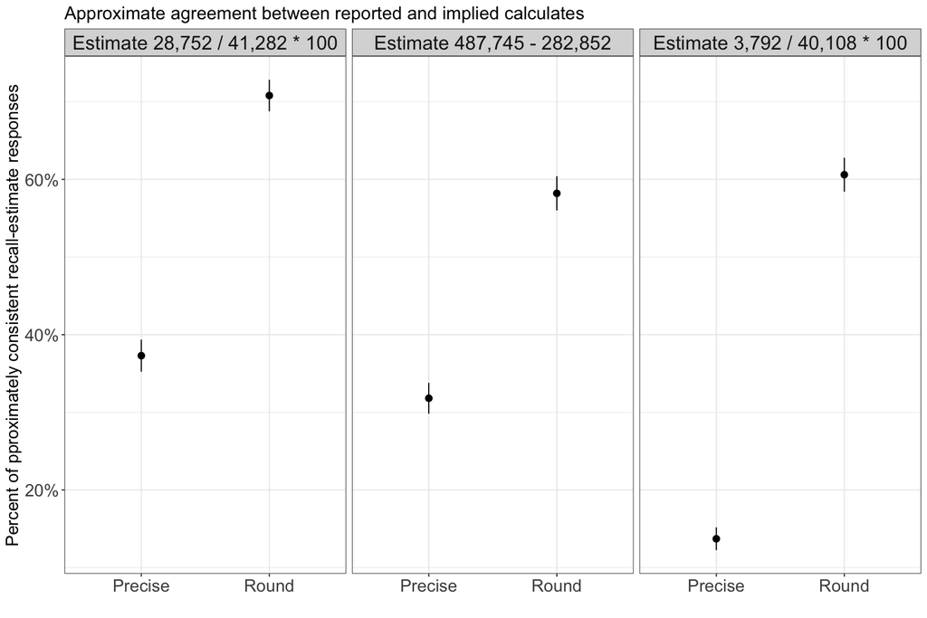

```r
options(repr.plot.width=12, repr.plot.height=8)
plot_data %>%
    mutate(name = name %>% display_label_calculate() %>% factor(levels = calculate_facet_order)) %>%
    ggplot(aes(x = condition, y = frac_close)) +
    geom_pointrange(aes(ymin = lower, ymax = upper)) +
    scale_y_continuous(label = percent) +
    facet_wrap(~ name) +
    text_setting() +
    labs(
        x = '',
       y = 'Percent of pproximately consistent recall-estimate responses',
       title = 'Approximate agreement between reported and implied calculates')

ggsave(filename = 'figures/approx_recall_estimate_consistent.png', width = 12, height = 8)
```

#### Exactly consistent

Now we require that participants' implied estimates must be equal to their reported estimates.

| condition | name | frac_exact | se | lower | upper | question_pretty |
| --- | --- | --- | --- | --- | --- | --- |
| Precise | enroll | 0.0566728 | 0.0098861 | 0.0467867 | 0.0665589 | Enrollment: percentage of accepted transfer applicaents |
| Precise | frick | 0.0347349 | 0.0078291 | 0.0269058 | 0.0425640 | Museum: Percentage of addition for art |
| Precise | hondura | 0.1809872 | 0.0164617 | 0.1645255 | 0.1974489 | Immigrants: Increase in Hondurans in the U.S. since 2000 |
| Round | enroll | 0.6160000 | 0.0217506 | 0.5942494 | 0.6377506 | Enrollment: percentage of accepted transfer applicaents |
| Round | frick | 0.5940000 | 0.0219620 | 0.5720380 | 0.6159620 | Museum: Percentage of addition for art |
| Round | hondura | 0.5820000 | 0.0220579 | 0.5599421 | 0.6040579 | Immigrants: Increase in Hondurans in the U.S. since 2000 |

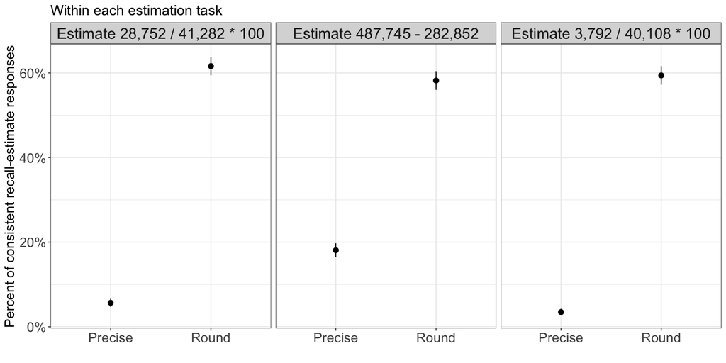

```r
facet_labels <- exact_values %>%
  filter(question_type == "calculate") %>%
  select(name = question, question_pretty)

plot_data <- implied_vs_reported_calc %>%
  mutate(reported_is_exactly_implied = abs(reported - implied) < 1e-4) %>%
  filter(is.finite(reported_is_exactly_implied)) %>%
  group_by(condition, name) %>%
  summarize(frac_exact = mean(reported_is_exactly_implied),
            se = sqrt(frac_exact * (1 - frac_exact) / n()),
            lower = frac_exact - se,
            upper = frac_exact + se) %>%
  left_join(facet_labels)

display_table(plot_data)

options(repr.plot.width=12, repr.plot.height=6)

plot_data %>%
    mutate(name = name %>% display_label_calculate() %>% factor(levels = calculate_facet_order)) %>%
    ggplot(aes(x = condition, y = frac_exact)) +
    geom_pointrange(aes(ymin = lower, ymax = upper)) +
    scale_y_continuous(label = percent) +
    facet_wrap(~ name) +
    text_setting() +
    labs(x = '',
       y = 'Percent of consistent recall-estimate responses',
        title = 'Within each estimation task')
ggsave(filename = 'figures/recall_estimate_consistent.png', width = 12, height = 6)
```